# Gym Goers Data Story

[figure not shown]

This is totally what I look like by the way…….

## What days are Rest Days? Do people even talk to me?

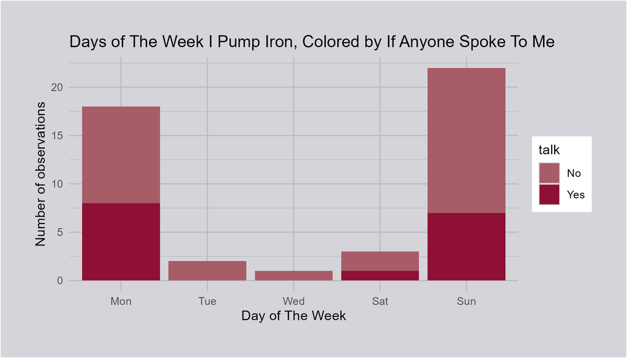

Days of the week I go to the Gym on a bar graph, colored by if anyone spoke to me

Here we have a **bar graph** of the days of the weeks I go to the gym! WOW! Not too many Thursdays or Fridays, huh? I’m going pretty consistently on the Mondays and Sundays though! I’ve also colored the bars by whether anyone spoke to me at the gym or not. If you focus on each individual bar, you see a good visualization of the *ratios* for each day.

I have an app called “hevy” that I use to track my workouts and Thursdays and Fridays tend to be my rest days, likely due to the fact that I have lectures early in the morning on those days. So this graph is pretty accurate. Keep in mind that sometimes I make logs on hevy without going to the gym (eg. home workouts)

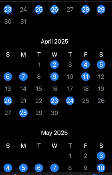

Image of hevy data, showing which days of April and May 2025 I logged that I worked out.

## Who’s running indoors on a Sunny day?

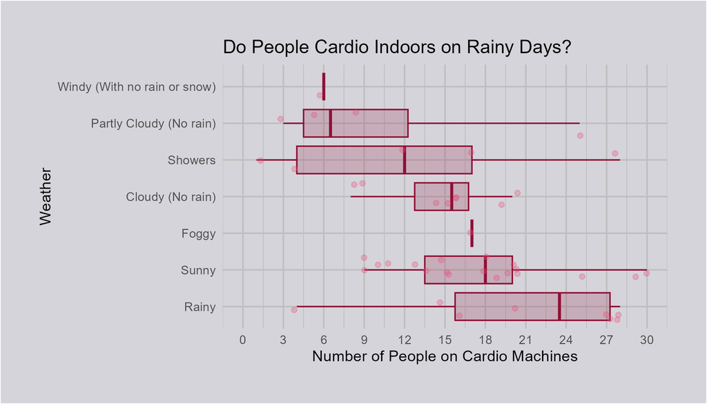

## More People in Gym = More People to talk to me?

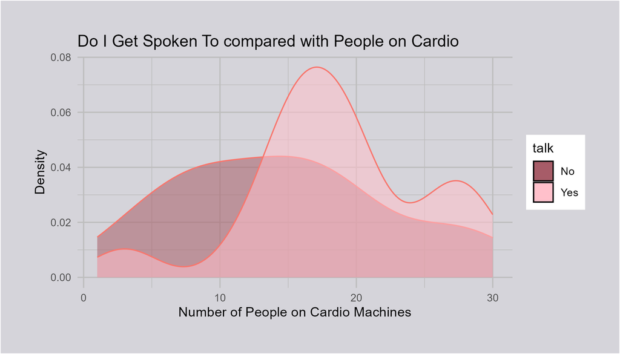

A density plot of number of people on cardio machines, seperated by if people talked to me or not

Ooh! So *smooth*! Here we have a **density plot** of the number of people on cardio machines, showing which numbers are more common than others by the seperation. The plots are seperated by if someone spoke to me or not. Seems that when people talk to me, the peak of number of people on cardio machines is about 18 and if they don’t it’s about 14. Maybe I should start going to the gym more on windy days when I don’t want anyone to speak to me!

[Github Link](https://nicole8312.github.io/stats220/visual_data_story.html)